# Risk Factor Analysis

## Outcome Variable

**Outcome Variable:** haz

## Predictor Variables

**Intervention Variable:** fhtcm

**Adjustment Set:**

- arm
- W_mage
- W_fage
- meducyrs
- feducyrs
- W_mhtcm
- W_mwtkg
- W_mbmi
- single
- delta_W_mage
- delta_W_fage
- delta_meducyrs
- delta_feducyrs
- delta_W_mhtcm
- delta_W_mwtkg
- delta_W_mbmi
- delta_single

## Stratifying Variables

The analysis was stratified on these variable(s):

- agecat

## Data Summary

| agecat | fhtcm | n_cell | n | outcome_variable |
| --- | --- | --- | --- | --- |
| Birth | >=167 cm | 12886 | 14654 | haz |
| Birth | <162 cm | 566 | 14654 | haz |
| Birth | [162-167) cm | 1202 | 14654 | haz |
| 6 months | >=167 cm | 12641 | 14920 | haz |
| 6 months | <162 cm | 808 | 14920 | haz |
| 6 months | [162-167) cm | 1471 | 14920 | haz |
| 24 months | >=167 cm | 4336 | 5493 | haz |
| 24 months | <162 cm | 457 | 5493 | haz |
| 24 months | [162-167) cm | 700 | 5493 | haz |

The following strata were considered:

- agecat: 24 months
- agecat: 6 months
- agecat: Birth

## Methods Detail

We’re interested in the causal parameters $E[Y_a]$ for all values of $a \in \mathcal{A}$. These parameters represent the mean outcome if, possibly contrary to fact, we intervened to set all units to have $A=a$. Under the randomization and positivity assumptions, these are identified by the statistical parameters $\psi_a=E_W[E_{Y|A,W}(Y|A=a,W)]$. In addition, we’re interested in the mean of $Y$, $E[Y]$ under no intervention (the observed mean). We will estimate these parameters by using SuperLearner to fit the relevant likelihood factors – $E_{Y|A,W}(Y|A=a,W)$ and $p(A=a|W)$, and then updating our likelihood fit using a joint TMLE.

For unadjusted analyses ($W=\{\}$), initial likelihoods were estimated using Lrnr_glm to estimate the simple $E(Y|A)$ and Lrnr_mean to estimate $p(A)$. For adjusted analyses, a small library containing Lrnr_glmnet, Lrnr_xgboost, and Lrnr_mean was used.

Having estimated these parameters, we will then use the delta method to estimate relative risks and attributable risks relative to a prespecified baseline level of $A$.

# Results Detail

## Results Plots

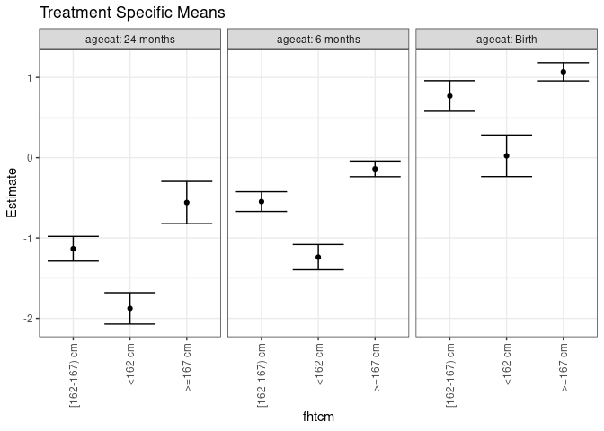

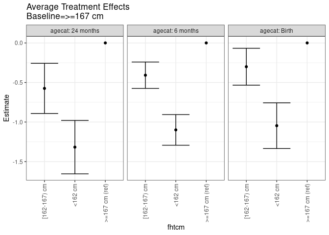

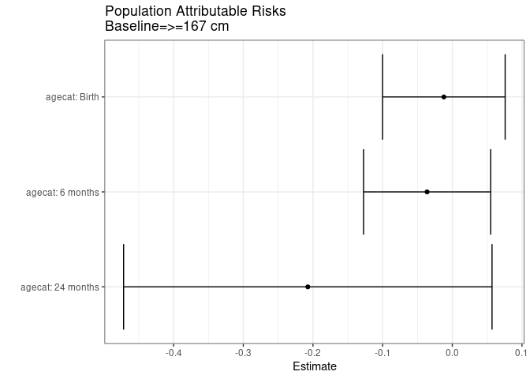

## Results Table

### Parameter: TSM

| agecat | intervention_level | baseline_level | estimate | ci_lower | ci_upper |
| --- | --- | --- | --- | --- | --- |
| Birth | >=167 cm | NA | 1.0692605 | 0.9560129 | 1.1825080 |
| Birth | <162 cm | NA | 0.0234942 | -0.2354244 | 0.2824128 |
| Birth | [162-167) cm | NA | 0.7687033 | 0.5786465 | 0.9587601 |
| 6 months | >=167 cm | NA | -0.1390819 | -0.2367902 | -0.0413735 |
| 6 months | <162 cm | NA | -1.2381165 | -1.3954621 | -1.0807709 |
| 6 months | [162-167) cm | NA | -0.5469323 | -0.6698589 | -0.4240056 |
| 24 months | >=167 cm | NA | -0.5586495 | -0.8220973 | -0.2952017 |
| 24 months | <162 cm | NA | -1.8755453 | -2.0706923 | -1.6803983 |
| 24 months | [162-167) cm | NA | -1.1332773 | -1.2866799 | -0.9798747 |

### Parameter: E(Y)

| agecat | intervention_level | baseline_level | estimate | ci_lower | ci_upper |
| --- | --- | --- | --- | --- | --- |
| Birth | NA | NA | 1.0571172 | 0.9904723 | 1.1237620 |
| 6 months | NA | NA | -0.1752574 | -0.2245260 | -0.1259887 |
| 24 months | NA | NA | -0.7660331 | -0.8232082 | -0.7088580 |

### Parameter: ATE

| agecat | intervention_level | baseline_level | estimate | ci_lower | ci_upper |
| --- | --- | --- | --- | --- | --- |
| Birth | >=167 cm | >=167 cm | 0.0000000 | 0.0000000 | 0.0000000 |
| Birth | <162 cm | >=167 cm | -1.0457663 | -1.3344024 | -0.7571301 |
| Birth | [162-167) cm | >=167 cm | -0.3005571 | -0.5335571 | -0.0675572 |
| 6 months | >=167 cm | >=167 cm | 0.0000000 | 0.0000000 | 0.0000000 |
| 6 months | <162 cm | >=167 cm | -1.0990346 | -1.2926805 | -0.9053887 |
| 6 months | [162-167) cm | >=167 cm | -0.4078504 | -0.5747643 | -0.2409365 |
| 24 months | >=167 cm | >=167 cm | 0.0000000 | 0.0000000 | 0.0000000 |
| 24 months | <162 cm | >=167 cm | -1.3168958 | -1.6543832 | -0.9794083 |
| 24 months | [162-167) cm | >=167 cm | -0.5746277 | -0.8915687 | -0.2576867 |

### Parameter: PAR

| agecat | intervention_level | baseline_level | estimate | ci_lower | ci_upper |
| --- | --- | --- | --- | --- | --- |
| Birth | >=167 cm | NA | -0.0121433 | -0.1001344 | 0.0758479 |
| 6 months | >=167 cm | NA | -0.0361755 | -0.1274060 | 0.0550550 |
| 24 months | >=167 cm | NA | -0.2073836 | -0.4717763 | 0.0570091 |